# SPX Volatility Term Structure Analysis

Click [here](https://github.com/jackliu234/spx-vol-term-struct/blob/master/project-lab.ipynb) to download this notebook.

## Section 1: Theoretical Background

### Part 1

In this exercise we analyze the volatility structure of daily SPX return over the period 1970-2018. We used the Dupire equation to calibrate our volatility curve parameter in order to fit the realized distribution of the SPX returns over time.

First, we assume that the volatility follows certain form. For example we start with a linear form:

$$ \sigma(r_T) = a * r_T + b $$

Where $r_T=log(S_T/S_0)$ is the stock return over a fixed period $T$. We under the Black-Scholes assumption with $0$ risk-free rate, the call option premium for $S_0=1$ can be calulated as:

$$ C(S_0=1, K) = \Phi(d1) - K\Phi(d2) \\ d_{1, 2} = \dfrac{log(1/K) \pm (\sigma^2/2)T}{\sigma\sqrt{T}} $$

Assuming that there is a density function for $S_T$, we have:

$$ C = \int^{\infty}_K(S_T-K)f_{S_T}(S_T)dS_T $$

Taking partial derivative w.r.t. $K$, we get the Dupire Formula:

$$ \dfrac{\partial C}{\partial K} = \int^{\infty}_K -f_{S_T}(S_T)dS_T \\ \dfrac{\partial^2 C}{\partial K^2} = f_{S_T}(K) $$

We can approximate the second-order derivative numerically:

$$ f_{S_T}(K) \approx \dfrac{C(K + \triangle K) - 2C(K) + C(K - \triangle K)}{(\triangle K)^2} $$

### Part 2

Now we define $x = log(K)$ and $\tilde{C}(x)$:

$$ \tilde{C}(x) = \Phi(d1) - e^x\Phi(d2) \\ d_{1, 2} = \dfrac{-x \pm (\sigma^2/2)T}{\sigma\sqrt{T}} $$

Now given any $\triangle K$, define $\triangle x$ such that:

$$ \triangle x = log(K + \triangle K) - log(K) \\ \text{therefore, } K + \triangle K = e^{x + \triangle x} \\ \text{and } \triangle K = e^{x}(e^{\triangle x} - 1) $$

We thus have equivalence between $C$ and $\tilde{C}$:

$$ C(K + \triangle K) = \tilde{C}(x + \triangle x) \\ \text{and } C(K - \triangle K) = \tilde{C}(log[e^x(2-e^{\triangle x})])$$

### Part 3

Based on chain rule, given $r_T = log(S_T)$:

$$ f_{r_T}(x) = f_{S_T}(K) \times K $$

Therefore:

$$\begin{align} f_{r_T}(x) = f_{S_T}(K) \times K &\approx \dfrac{C(K + \triangle K) - 2C(K) + C(K - \triangle K)}{(\triangle K)^2} \times K\\ &= \dfrac{\tilde{C}(x + \triangle x) - 2\tilde{C}(x) + \tilde{C}(log[e^x(2-e^{\triangle x})])}{[e^x(e^{\triangle x} - 1)]^2} \times e^{x}\\ \end{align}$$

So finally we have:

$$ f_{r_T}(x) = \dfrac{\tilde{C}(x + \triangle x) - 2\tilde{C}(x) + \tilde{C}(log[e^x(2-e^{\triangle x})])}{e^x[(e^{\triangle x} - 1)]^2} \\ \text{where } C(x) = \Phi(\dfrac{-x + (\sigma^2/2)T}{\sigma\sqrt{T}}) - e^x\Phi(\dfrac{-x - (\sigma^2/2)T}{\sigma\sqrt{T}}) \\ \text{and } \sigma = ax + b $$

So the goal of this exercise is to find the optimal parameters a, b such that $f_{r_T}(x)$ is close to the realized distribution of $r_T$.

## Section 2: Python Code

### Part 1: Import Packages

```python
import sys
import time
import json
import warnings
import numpy as np
import scipy as sp
import pandas as pd
import seaborn as sns
import matplotlib.pyplot as plt
from scipy.stats import norm
from mpl_toolkits import mplot3d
from urllib.request import urlopen
from scipy.optimize import minimize
from sklearn.neighbors import KernelDensity
from pandas.plotting import register_matplotlib_converters
register_matplotlib_converters()
warnings.filterwarnings('ignore')
```

### Part 2: Declare Functions

```python
def yahoo_parser(url):
    response = urlopen(url)
    data = json.loads(response.read().decode("utf-8"))['chart']['result'][0]
    t = pd.to_datetime(data['timestamp'], unit='s').date
    c = data['indicators']['quote'][0]['close']
    return pd.DataFrame({'close': c}, index=t)


def default_parser(url):
    return pd.read_csv(url, index_col=0, parse_dates=True)


def retrieve(source, code, label, column=None):
    query = {
        'yahoo': 'https://query1.finance.yahoo.com/v8/finance/chart/{}?period1=0&period2=5000000000&interval=1d',
    }
    parser = {
        'yahoo': yahoo_parser,
    }
    url = query.get(source).format(code)
    df = parser.get(source, default_parser)(url)
    df.index.name = None
    df.columns = [col.lower() for col in df.columns] if df.shape[1] > 1 else [label]
    if not column: column = df.columns
    all_dates = pd.date_range(df.index.min(), df.index.max(), freq='D')
    df = df.replace('.', None).reindex(all_dates).fillna(method='ffill')
    return df.astype('float')[column].squeeze()


def sigma_func_linear(x, a, b):
    return a * x + b


def sigma_func_quad(x, a, b, c):
    return a * x**2 + b * x + c


def calc_call_premium(x, sigma, T):
    if sigma == 0:
        return 0
    else:
        d1 = (- x + sigma**2 / 2 * T)/(sigma * np.sqrt(T))
        d2 = (- x - sigma**2 / 2 * T)/(sigma * np.sqrt(T))
        c = norm.cdf(d1) - np.exp(x) * norm.cdf(d2)
        return c


def calc_density(x, r, T, sigma, delta_x):
    f = np.exp(r * T) * (calc_call_premium(x + delta_x, sigma, T)
                       - 2 * calc_call_premium(x, sigma, T)
                       + calc_call_premium(np.log(np.exp(x) * (2 - np.exp(delta_x))), sigma, T)) / (np.exp(x) * (np.exp(delta_x) - 1)**2)
    return f


'''
def calc_density_K(K, r, T, sigma, delta_K):
    f = np.exp(r * T) * (calc_call_premium(K + delta_K, sigma, T)
                       - 2 * calc_call_premium(x, sigma, T)
                       + calc_call_premium(x - delta_x, sigma, T)) / ((np.exp(x) * (np.exp(delta_x) - 1))**2)
    return f
'''


def obj_func(params, r_series, term_day, kde, method):
    """
    :param params: one-dimension vector/list,
                    if linear, np.array([intercept, beta_1]);
                    if quad, np.array([intercept, beta_1, beta_2])
    :param r_series: pd.Series, of return / log(K/S0), of which we should calculate the prob density
    :param term_day: days to maturity of option
    :param kde: sklearn.neighbors.KernelDensity
    :param method: 'linear' / 'quad', otherwise raise Error

    :return: float
        Mean of Squared Errors
        Why use mean instead of sum: reduce the value of obj_func so that the solver is less sensitive
    """
    kde.fit(np.reshape(r_series.values, (-1, 1)))
    avg, std = r_series.mean(), r_series.std()
    r_sample = (np.arange(avg-3.5*std, avg+3*std, 0.05*std)).reshape(-1, 1)
    density_true = (np.exp(kde.score_samples(r_sample))).reshape(-1, 1)
    if method == 'linear' and len(params) == 2:
        density_pred = [calc_density(elem, r=0, T=term_day/260,
                                     sigma=sigma_func_linear(elem, params[0], params[1]),
                                     delta_x=0.01) for elem in r_sample]
    elif method == 'quad' and len(params) == 3:
        density_pred = [calc_density(elem, r=0, T=term_day/260,
                                     sigma=sigma_func_quad(elem, params[0], params[1], params[2]),
                                     delta_x=0.01) for elem in r_sample]
    else:
        raise Exception("Wrong param dimension or fit method!")
    sse = ((density_true - density_pred) ** 2).mean()
    return sse
```

### Part 3: Format Data

```python
# load yahoo data
raw_df = retrieve('yahoo', '^GSPC', 'SPX').to_frame()
```

```python
raw_df
```

|  | SPX |
| --- | --- |
| 1970-01-02 | 93.000000 |
| 1970-01-03 | 93.000000 |
| 1970-01-04 | 93.000000 |
| 1970-01-05 | 93.459999 |
| 1970-01-06 | 92.820000 |
| 1970-01-07 | 92.629997 |
| 1970-01-08 | 92.680000 |
| 1970-01-09 | 92.400002 |
| 1970-01-10 | 92.400002 |
| 1970-01-11 | 92.400002 |
| 1970-01-12 | 91.699997 |
| 1970-01-13 | 91.919998 |
| 1970-01-14 | 91.650002 |
| 1970-01-15 | 91.680000 |
| 1970-01-16 | 90.919998 |
| 1970-01-17 | 90.919998 |
| 1970-01-18 | 90.919998 |
| 1970-01-19 | 89.650002 |
| 1970-01-20 | 89.830002 |
| 1970-01-21 | 89.949997 |
| 1970-01-22 | 90.040001 |
| 1970-01-23 | 89.370003 |
| 1970-01-24 | 89.370003 |
| 1970-01-25 | 89.370003 |
| 1970-01-26 | 88.169998 |
| 1970-01-27 | 87.620003 |
| 1970-01-28 | 86.790001 |
| 1970-01-29 | 85.690002 |
| 1970-01-30 | 85.019997 |
| 1970-01-31 | 85.019997 |
| ... | ... |
| 2019-03-31 | 2834.399902 |
| 2019-04-01 | 2867.189941 |
| 2019-04-02 | 2867.239990 |
| 2019-04-03 | 2873.399902 |
| 2019-04-04 | 2879.389893 |
| 2019-04-05 | 2892.739990 |
| 2019-04-06 | 2892.739990 |
| 2019-04-07 | 2892.739990 |
| 2019-04-08 | 2895.770020 |
| 2019-04-09 | 2878.199951 |
| 2019-04-10 | 2888.209961 |
| 2019-04-11 | 2888.320068 |
| 2019-04-12 | 2907.409912 |
| 2019-04-13 | 2907.409912 |
| 2019-04-14 | 2907.409912 |
| 2019-04-15 | 2905.580078 |
| 2019-04-16 | 2907.060059 |
| 2019-04-17 | 2900.449951 |
| 2019-04-18 | 2905.030029 |
| 2019-04-19 | 2905.030029 |
| 2019-04-20 | 2905.030029 |
| 2019-04-21 | 2905.030029 |
| 2019-04-22 | 2907.969971 |
| 2019-04-23 | 2933.679932 |
| 2019-04-24 | 2927.250000 |
| 2019-04-25 | 2926.169922 |
| 2019-04-26 | 2939.879883 |
| 2019-04-27 | 2939.879883 |
| 2019-04-28 | 2939.879883 |
| 2019-04-29 | 2943.030029 |

18015 rows × 1 columns

```python
# remove all weekends
df = raw_df.copy()
df = df.reindex(pd.date_range(start="1970-01-02", end="2018-12-31", freq='B'))

# take the log price and return
df['log_SPX'] = np.log(df["SPX"])
df['r'] = df['log_SPX'] - df['log_SPX'].shift(1)
df['r_ann'] = df['r'] * 252

term_days = [5, 10] + list(range(20, 521, 20))
term_name = [str(i) + "D" for i in term_days]
terms = dict(zip(term_name, term_days))

# calculate rolling volatilities
for k, v in terms.items():
    df['mean_'+ k ] = df["r"].rolling(v).mean() * 252

# remove na
# df.fillna(value=0, inplace=True)
```

```python
df
```

|  | SPX | log_SPX | r | r_ann | mean_5D | mean_10D | mean_20D | mean_40D | mean_60D | mean_80D | ... | mean_340D | mean_360D | mean_380D | mean_400D | mean_420D | mean_440D | mean_460D | mean_480D | mean_500D | mean_520D |
| --- | --- | --- | --- | --- | --- | --- | --- | --- | --- | --- | --- | --- | --- | --- | --- | --- | --- | --- | --- | --- | --- |
| 1970-01-02 | 93.000000 | 4.532599 | NaN | NaN | NaN | NaN | NaN | NaN | NaN | NaN | ... | NaN | NaN | NaN | NaN | NaN | NaN | NaN | NaN | NaN | NaN |
| 1970-01-05 | 93.459999 | 4.537534 | 0.004934 | 1.243377 | NaN | NaN | NaN | NaN | NaN | NaN | ... | NaN | NaN | NaN | NaN | NaN | NaN | NaN | NaN | NaN | NaN |
| 1970-01-06 | 92.820000 | 4.530662 | -0.006871 | -1.731592 | NaN | NaN | NaN | NaN | NaN | NaN | ... | NaN | NaN | NaN | NaN | NaN | NaN | NaN | NaN | NaN | NaN |
| 1970-01-07 | 92.629997 | 4.528613 | -0.002049 | -0.516372 | NaN | NaN | NaN | NaN | NaN | NaN | ... | NaN | NaN | NaN | NaN | NaN | NaN | NaN | NaN | NaN | NaN |
| 1970-01-08 | 92.680000 | 4.529153 | 0.000540 | 0.135997 | NaN | NaN | NaN | NaN | NaN | NaN | ... | NaN | NaN | NaN | NaN | NaN | NaN | NaN | NaN | NaN | NaN |
| 1970-01-09 | 92.400002 | 4.526127 | -0.003026 | -0.762478 | -0.326214 | NaN | NaN | NaN | NaN | NaN | ... | NaN | NaN | NaN | NaN | NaN | NaN | NaN | NaN | NaN | NaN |
| 1970-01-12 | 91.699997 | 4.518522 | -0.007605 | -1.916372 | -0.958164 | NaN | NaN | NaN | NaN | NaN | ... | NaN | NaN | NaN | NaN | NaN | NaN | NaN | NaN | NaN | NaN |
| 1970-01-13 | 91.919998 | 4.520919 | 0.002396 | 0.603859 | -0.491073 | NaN | NaN | NaN | NaN | NaN | ... | NaN | NaN | NaN | NaN | NaN | NaN | NaN | NaN | NaN | NaN |
| 1970-01-14 | 91.650002 | 4.517977 | -0.002942 | -0.741289 | -0.536057 | NaN | NaN | NaN | NaN | NaN | ... | NaN | NaN | NaN | NaN | NaN | NaN | NaN | NaN | NaN | NaN |
| 1970-01-15 | 91.680000 | 4.518304 | 0.000327 | 0.082471 | -0.546762 | NaN | NaN | NaN | NaN | NaN | ... | NaN | NaN | NaN | NaN | NaN | NaN | NaN | NaN | NaN | NaN |
| 1970-01-16 | 90.919998 | 4.509980 | -0.008324 | -2.097718 | -0.813810 | -0.570012 | NaN | NaN | NaN | NaN | ... | NaN | NaN | NaN | NaN | NaN | NaN | NaN | NaN | NaN | NaN |
| 1970-01-19 | 89.650002 | 4.495913 | -0.014067 | -3.544824 | -1.139500 | -1.048832 | NaN | NaN | NaN | NaN | ... | NaN | NaN | NaN | NaN | NaN | NaN | NaN | NaN | NaN | NaN |
| 1970-01-20 | 89.830002 | 4.497919 | 0.002006 | 0.505461 | -1.159180 | -0.825126 | NaN | NaN | NaN | NaN | ... | NaN | NaN | NaN | NaN | NaN | NaN | NaN | NaN | NaN | NaN |
| 1970-01-21 | 89.949997 | 4.499254 | 0.001335 | 0.336398 | -0.943642 | -0.739850 | NaN | NaN | NaN | NaN | ... | NaN | NaN | NaN | NaN | NaN | NaN | NaN | NaN | NaN | NaN |
| 1970-01-22 | 90.040001 | 4.500254 | 0.001000 | 0.252025 | -0.909732 | -0.728247 | NaN | NaN | NaN | NaN | ... | NaN | NaN | NaN | NaN | NaN | NaN | NaN | NaN | NaN | NaN |
| 1970-01-23 | 89.370003 | 4.492785 | -0.007469 | -1.882173 | -0.866623 | -0.840216 | NaN | NaN | NaN | NaN | ... | NaN | NaN | NaN | NaN | NaN | NaN | NaN | NaN | NaN | NaN |
| 1970-01-26 | 88.169998 | 4.479267 | -0.013518 | -3.406621 | -0.838982 | -0.989241 | NaN | NaN | NaN | NaN | ... | NaN | NaN | NaN | NaN | NaN | NaN | NaN | NaN | NaN | NaN |
| 1970-01-27 | 87.620003 | 4.473009 | -0.006257 | -1.576874 | -1.255449 | -1.207314 | NaN | NaN | NaN | NaN | ... | NaN | NaN | NaN | NaN | NaN | NaN | NaN | NaN | NaN | NaN |
| 1970-01-28 | 86.790001 | 4.463491 | -0.009518 | -2.398510 | -1.802430 | -1.373036 | NaN | NaN | NaN | NaN | ... | NaN | NaN | NaN | NaN | NaN | NaN | NaN | NaN | NaN | NaN |
| 1970-01-29 | 85.690002 | 4.450736 | -0.012755 | -3.214325 | -2.495700 | -1.702716 | NaN | NaN | NaN | NaN | ... | NaN | NaN | NaN | NaN | NaN | NaN | NaN | NaN | NaN | NaN |
| 1970-01-30 | 85.019997 | 4.442886 | -0.007850 | -1.978119 | -2.514890 | -1.690756 | -1.130384 | NaN | NaN | NaN | ... | NaN | NaN | NaN | NaN | NaN | NaN | NaN | NaN | NaN | NaN |
| 1970-02-02 | 85.750000 | 4.451436 | 0.008550 | 2.154500 | -1.402665 | -1.120824 | -1.084828 | NaN | NaN | NaN | ... | NaN | NaN | NaN | NaN | NaN | NaN | NaN | NaN | NaN | NaN |
| 1970-02-03 | 86.769997 | 4.463261 | 0.011825 | 2.979853 | -0.491320 | -0.873384 | -0.849255 | NaN | NaN | NaN | ... | NaN | NaN | NaN | NaN | NaN | NaN | NaN | NaN | NaN | NaN |
| 1970-02-04 | 86.239998 | 4.457134 | -0.006127 | -1.543958 | -0.320410 | -1.061420 | -0.900635 | NaN | NaN | NaN | ... | NaN | NaN | NaN | NaN | NaN | NaN | NaN | NaN | NaN | NaN |
| 1970-02-05 | 85.900002 | 4.453184 | -0.003950 | -0.995459 | 0.123363 | -1.186169 | -0.957208 | NaN | NaN | NaN | ... | NaN | NaN | NaN | NaN | NaN | NaN | NaN | NaN | NaN | NaN |
| 1970-02-06 | 86.330002 | 4.458177 | 0.004993 | 1.258321 | 0.770651 | -0.872119 | -0.856168 | NaN | NaN | NaN | ... | NaN | NaN | NaN | NaN | NaN | NaN | NaN | NaN | NaN | NaN |
| 1970-02-09 | 87.010002 | 4.466023 | 0.007846 | 1.977166 | 0.735184 | -0.333740 | -0.661491 | NaN | NaN | NaN | ... | NaN | NaN | NaN | NaN | NaN | NaN | NaN | NaN | NaN | NaN |
| 1970-02-10 | 86.099998 | 4.455509 | -0.010514 | -2.649449 | -0.390676 | -0.440998 | -0.824156 | NaN | NaN | NaN | ... | NaN | NaN | NaN | NaN | NaN | NaN | NaN | NaN | NaN | NaN |
| 1970-02-11 | 86.940002 | 4.465218 | 0.009709 | 2.446633 | 0.407442 | 0.043516 | -0.664760 | NaN | NaN | NaN | ... | NaN | NaN | NaN | NaN | NaN | NaN | NaN | NaN | NaN | NaN |
| 1970-02-12 | 86.730003 | 4.462800 | -0.002418 | -0.609429 | 0.484648 | 0.304006 | -0.699355 | NaN | NaN | NaN | ... | NaN | NaN | NaN | NaN | NaN | NaN | NaN | NaN | NaN | NaN |
| ... | ... | ... | ... | ... | ... | ... | ... | ... | ... | ... | ... | ... | ... | ... | ... | ... | ... | ... | ... | ... | ... |
| 2018-11-20 | 2641.889893 | 7.879250 | -0.018318 | -4.616135 | -1.508899 | -1.060573 | -0.462611 | -0.620975 | -0.387915 | -0.201367 | ... | 0.047961 | 0.058808 | 0.055625 | 0.061305 | 0.069283 | 0.063301 | 0.067042 | 0.080138 | 0.076295 | 0.088055 |
| 2018-11-21 | 2649.929932 | 7.882288 | 0.003039 | 0.765745 | -0.972902 | -1.512873 | -0.029304 | -0.581074 | -0.399030 | -0.188516 | ... | 0.049848 | 0.059918 | 0.056601 | 0.062508 | 0.073367 | 0.060265 | 0.065979 | 0.080809 | 0.079067 | 0.089137 |
| 2018-11-22 | 2649.929932 | 7.882288 | 0.000000 | 0.000000 | -1.504019 | -1.449569 | -0.261821 | -0.598459 | -0.380382 | -0.203996 | ... | 0.051468 | 0.066507 | 0.056424 | 0.063872 | 0.077469 | 0.061198 | 0.066452 | 0.082707 | 0.080007 | 0.089137 |
| 2018-11-23 | 2632.560059 | 7.875712 | -0.006576 | -1.657258 | -1.947401 | -1.382406 | -0.124447 | -0.639847 | -0.408567 | -0.239307 | ... | 0.045195 | 0.057436 | 0.052613 | 0.060661 | 0.073524 | 0.058184 | 0.061931 | 0.077490 | 0.076062 | 0.084056 |
| 2018-11-26 | 2673.449951 | 7.891125 | 0.015413 | 3.884070 | -0.324716 | -0.492566 | 0.152680 | -0.565643 | -0.343833 | -0.201882 | ... | 0.055399 | 0.067576 | 0.063484 | 0.067369 | 0.077625 | 0.068164 | 0.070374 | 0.086996 | 0.083830 | 0.094079 |
| 2018-11-27 | 2682.169922 | 7.894381 | 0.003256 | 0.820609 | 0.762633 | -0.373133 | -0.002161 | -0.542628 | -0.323202 | -0.200508 | ... | 0.059604 | 0.070403 | 0.062658 | 0.069853 | 0.081324 | 0.077180 | 0.068855 | 0.085270 | 0.084339 | 0.095010 |
| 2018-11-28 | 2743.790039 | 7.917095 | 0.022714 | 5.723941 | 1.754272 | 0.390685 | 0.148046 | -0.404010 | -0.216014 | -0.128132 | ... | 0.076709 | 0.081208 | 0.078382 | 0.095721 | 0.095983 | 0.089108 | 0.081891 | 0.092998 | 0.100017 | 0.107305 |
| 2018-11-29 | 2737.800049 | 7.914910 | -0.002185 | -0.550745 | 1.644123 | 0.070052 | -0.011823 | -0.366100 | -0.209825 | -0.130472 | ... | 0.085895 | 0.078367 | 0.078419 | 0.092026 | 0.090154 | 0.088463 | 0.080465 | 0.092237 | 0.099063 | 0.107953 |
| 2018-11-30 | 2760.169922 | 7.923048 | 0.008138 | 2.050662 | 2.385707 | 0.219153 | 0.170553 | -0.279910 | -0.166341 | -0.082350 | ... | 0.090982 | 0.080799 | 0.083628 | 0.092903 | 0.096861 | 0.093608 | 0.084105 | 0.096965 | 0.105507 | 0.111704 |
| 2018-12-03 | 2790.370117 | 7.933930 | 0.010882 | 2.742264 | 2.157346 | 0.916315 | 0.237299 | -0.208864 | -0.128600 | -0.035427 | ... | 0.091640 | 0.088454 | 0.085332 | 0.096516 | 0.096921 | 0.100424 | 0.089509 | 0.105842 | 0.110991 | 0.114165 |
| 2018-12-04 | 2700.060059 | 7.901029 | -0.032900 | -8.290858 | 0.335053 | 0.548843 | -0.255865 | -0.407196 | -0.282459 | -0.159125 | ... | 0.067625 | 0.065005 | 0.067970 | 0.074632 | 0.073537 | 0.077443 | 0.072900 | 0.089037 | 0.090150 | 0.096571 |
| 2018-12-05 | 2700.060059 | 7.901029 | 0.000000 | 0.000000 | -0.809735 | 0.472269 | -0.520302 | -0.196673 | -0.283956 | -0.135087 | ... | 0.066573 | 0.061254 | 0.068356 | 0.073066 | 0.073829 | 0.076822 | 0.065460 | 0.088880 | 0.087275 | 0.090233 |
| 2018-12-06 | 2695.949951 | 7.899506 | -0.001523 | -0.383894 | -0.776365 | 0.433879 | -0.507845 | -0.075309 | -0.312482 | -0.164733 | ... | 0.076975 | 0.060296 | 0.067648 | 0.069314 | 0.072583 | 0.074271 | 0.067845 | 0.087781 | 0.086895 | 0.088450 |
| 2018-12-07 | 2633.080078 | 7.875910 | -0.023596 | -5.946277 | -2.375753 | 0.004977 | -0.688715 | -0.312835 | -0.412743 | -0.249512 | ... | 0.060848 | 0.044036 | 0.050966 | 0.054253 | 0.059574 | 0.062050 | 0.054642 | 0.071593 | 0.073233 | 0.074145 |
| 2018-12-10 | 2637.719971 | 7.877670 | 0.001761 | 0.443672 | -2.835471 | -0.339062 | -0.415814 | -0.264432 | -0.381891 | -0.251605 | ... | 0.061291 | 0.046013 | 0.051924 | 0.055362 | 0.059592 | 0.063999 | 0.057405 | 0.073629 | 0.075912 | 0.075550 |
| 2018-12-11 | 2636.780029 | 7.877314 | -0.000356 | -0.089815 | -1.195263 | -0.430105 | -0.401619 | -0.400664 | -0.405877 | -0.259237 | ... | 0.053696 | 0.043721 | 0.057063 | 0.055897 | 0.058665 | 0.063475 | 0.058808 | 0.073323 | 0.075733 | 0.072218 |
| 2018-12-12 | 2651.070068 | 7.882719 | 0.005405 | 1.362027 | -0.922857 | -0.866296 | -0.237806 | -0.365022 | -0.388437 | -0.240958 | ... | 0.060266 | 0.047306 | 0.054832 | 0.059592 | 0.062672 | 0.068323 | 0.063022 | 0.075797 | 0.077033 | 0.078787 |
| 2018-12-13 | 2650.540039 | 7.882519 | -0.000200 | -0.050387 | -0.856156 | -0.816260 | -0.373104 | -0.274953 | -0.422079 | -0.236255 | ... | 0.061657 | 0.047847 | 0.060427 | 0.054714 | 0.062203 | 0.067104 | 0.062474 | 0.072680 | 0.078014 | 0.076812 |
| 2018-12-14 | 2599.949951 | 7.863247 | -0.019271 | -4.856345 | -0.638170 | -1.506961 | -0.643904 | -0.394086 | -0.501470 | -0.316426 | ... | 0.046134 | 0.035297 | 0.046631 | 0.040241 | 0.048192 | 0.056541 | 0.050129 | 0.060694 | 0.067370 | 0.068322 |
| 2018-12-17 | 2545.939941 | 7.842255 | -0.020992 | -5.290056 | -1.784915 | -2.310193 | -0.696939 | -0.499192 | -0.574845 | -0.406621 | ... | 0.030215 | 0.021112 | 0.031179 | 0.027784 | 0.035574 | 0.044124 | 0.038428 | 0.046926 | 0.056790 | 0.057192 |
| 2018-12-18 | 2546.159912 | 7.842342 | 0.000086 | 0.021772 | -1.762598 | -1.478930 | -0.465044 | -0.463827 | -0.568998 | -0.407197 | ... | 0.029654 | 0.019460 | 0.031236 | 0.029592 | 0.036241 | 0.044996 | 0.040330 | 0.044872 | 0.058331 | 0.055475 |
| 2018-12-19 | 2506.959961 | 7.826826 | -0.015515 | -3.909896 | -2.816982 | -1.869920 | -0.698826 | -0.364065 | -0.620325 | -0.473979 | ... | 0.014742 | 0.008255 | 0.019984 | 0.018830 | 0.026254 | 0.038267 | 0.027261 | 0.034112 | 0.049623 | 0.049148 |
| 2018-12-20 | 2467.419922 | 7.810928 | -0.015898 | -4.006248 | -3.608155 | -2.232155 | -0.899138 | -0.580479 | -0.698685 | -0.510071 | ... | -0.001270 | -0.001343 | 0.015684 | 0.008646 | 0.018014 | 0.033078 | 0.019444 | 0.026219 | 0.043433 | 0.042347 |
| 2018-12-21 | 2416.620117 | 7.790125 | -0.020803 | -5.242386 | -3.685363 | -2.161766 | -1.078394 | -0.601421 | -0.786030 | -0.576024 | ... | -0.018156 | -0.017227 | -0.002345 | -0.003937 | 0.006420 | 0.021164 | 0.008768 | 0.014417 | 0.031255 | 0.031660 |
| 2018-12-24 | 2351.100098 | 7.762639 | -0.027487 | -6.926616 | -4.012675 | -2.898795 | -1.618929 | -0.733124 | -0.916738 | -0.662607 | ... | -0.038529 | -0.037619 | -0.021188 | -0.020637 | -0.012931 | 0.000509 | -0.005188 | -0.000013 | 0.018759 | 0.018339 |
| 2018-12-25 | 2351.100098 | 7.762639 | 0.000000 | 0.000000 | -4.017029 | -2.889814 | -1.659959 | -0.831060 | -0.915072 | -0.657391 | ... | -0.032911 | -0.035927 | -0.020668 | -0.023473 | -0.012519 | 0.002175 | 0.001652 | -0.003179 | 0.015461 | 0.017251 |
| 2018-12-26 | 2467.699951 | 7.811042 | 0.048403 | 12.197601 | -0.795530 | -1.806256 | -1.336276 | -0.594115 | -0.714766 | -0.496079 | ... | 0.000649 | -0.001790 | 0.006603 | 0.007649 | 0.027530 | 0.030880 | 0.027134 | 0.022801 | 0.035827 | 0.044775 |
| 2018-12-27 | 2488.830078 | 7.819568 | 0.008526 | 2.148610 | 0.435442 | -1.586357 | -1.201308 | -0.606566 | -0.644503 | -0.457696 | ... | 0.007101 | 0.014384 | 0.011016 | 0.014433 | 0.030438 | 0.031452 | 0.032386 | 0.027057 | 0.040495 | 0.049049 |
| 2018-12-28 | 2485.739990 | 7.818326 | -0.001242 | -0.313073 | 1.421304 | -1.132029 | -1.319495 | -0.574471 | -0.626439 | -0.454629 | ... | 0.007284 | 0.012622 | 0.007100 | 0.013472 | 0.025646 | 0.032481 | 0.032168 | 0.025622 | 0.040306 | 0.050699 |
| 2018-12-31 | 2506.850098 | 7.826782 | 0.008457 | 2.131070 | 3.232841 | -0.389917 | -1.350055 | -0.556378 | -0.589261 | -0.433964 | ... | 0.005561 | 0.011546 | 0.012743 | 0.013562 | 0.027632 | 0.031149 | 0.037360 | 0.029527 | 0.047606 | 0.054797 |

12782 rows × 32 columns

```python
np.mean(df)
```

```
SPX          776.934755
log_SPX        6.116116
r              0.000258
r_ann          0.064951
mean_5D        0.064612
mean_10D       0.064738
mean_20D       0.065904
mean_40D       0.067050
mean_60D       0.067430
mean_80D       0.068025
mean_100D      0.068818
mean_120D      0.069473
mean_140D      0.069940
mean_160D      0.070212
mean_180D      0.070307
mean_200D      0.070300
mean_220D      0.070355
mean_240D      0.070395
mean_260D      0.070392
mean_280D      0.070296
mean_300D      0.070140
mean_320D      0.069971
mean_340D      0.069779
mean_360D      0.069583
mean_380D      0.069453
mean_400D      0.069344
mean_420D      0.069279
mean_440D      0.069186
mean_460D      0.069102
mean_480D      0.069066
mean_500D      0.069056
mean_520D      0.068982
dtype: float64
```

### Part 4: Data Visualization

Time series plot.

```python
cmap = ['#ff0000', '#ff7a00', '#f6ad48', '#c4c6bd', '#3193d8', '#005684']
```

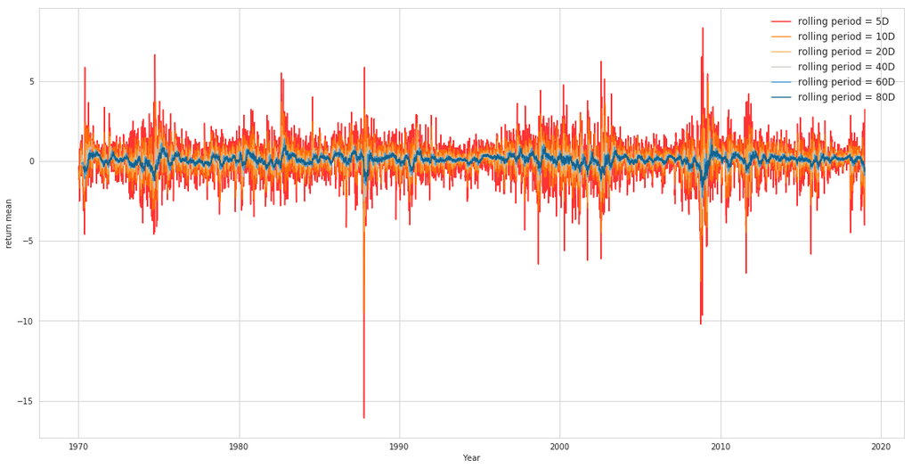

```python
# too many windows, only display six
fig = plt.figure(figsize=(16, 32))
index = 1
for moment in ['mean']:
    ax = fig.add_subplot(4, 1, index)
    cint = 0
    for term in terms.keys():
        ax.plot(df[moment+"_"+term], color=cmap[cint], label='rolling period = '+term, alpha=.8)
        cint += 1
        if cint==6:
            break
    plt.xlabel('Year')
    plt.ylabel('return '+moment)
    plt.legend(frameon=False, prop={'size': 12})
    plt.tight_layout()
    index += 1
```

Return distribution.

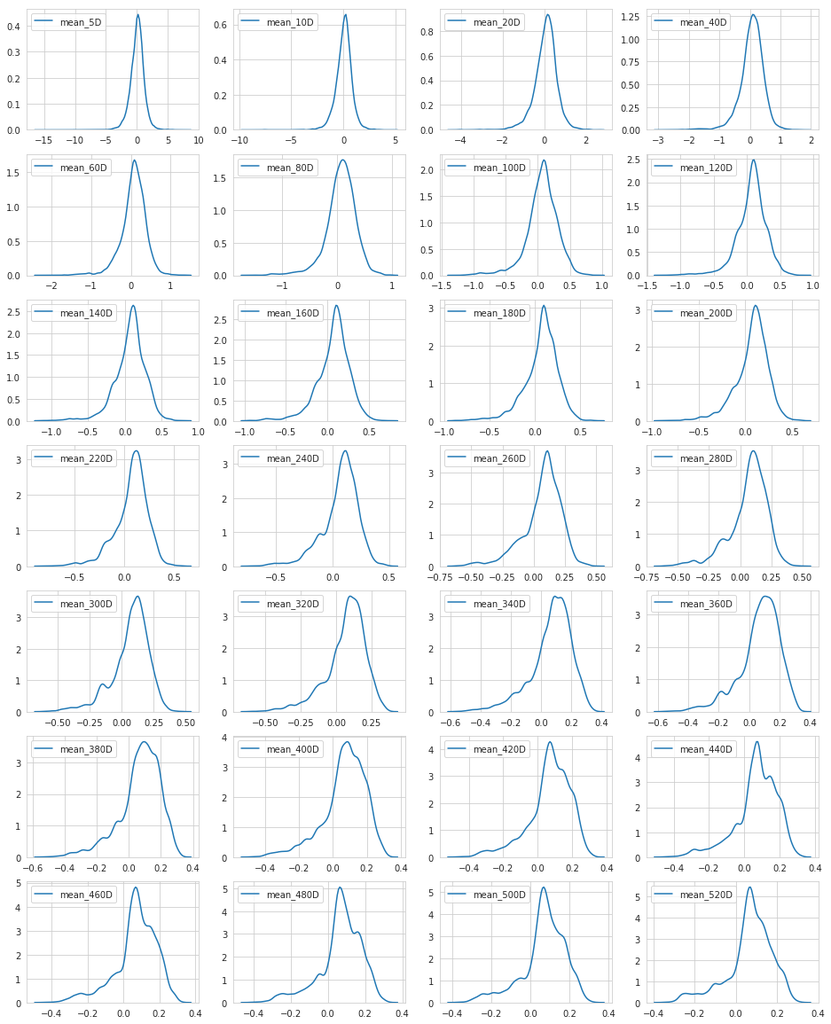

```python
num_window = len(terms)
sns.set_style('whitegrid')
fig = plt.figure(figsize=(16, num_window*3))

index = 1
for term in terms:
    for i in ['mean_']:
        plt.subplot(num_window, 4, index)
        sns.kdeplot(df[i+term])
        index += 1
```

### Part 5: Fitting 20D Window

Empirical distribution for window size 20D.

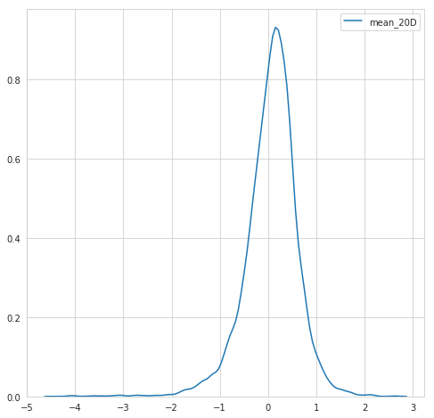

```python
fig = plt.figure(figsize=(8, 8))
sns.kdeplot(df["mean_20D"])
```

```python
# pick sample data points for fitting
avg, std = df["mean_20D"].mean(), df["mean_20D"].std()
r_sample = [round(elem, 4) for elem in np.arange(avg - 5 * std, avg + 5 * std, 0.2 * std)]
test = pd.DataFrame(r_sample, columns=['r'])
```

```python
# calculate the kde density of the data points
kde = KernelDensity(bandwidth = 0.1) # larger the bandwidth, smoother the curve
kde.fit(df[['mean_20D']].dropna())
test['f_r'] = [round(elem, 4) for elem in np.exp(kde.score_samples(test[['r']]))]
test.tail()
```

|  | r | f_r |
| --- | --- | --- |
| 45 | 2.2690 | 0.0016 |
| 46 | 2.3792 | 0.0004 |
| 47 | 2.4893 | 0.0005 |
| 48 | 2.5995 | 0.0008 |
| 49 | 2.7096 | 0.0006 |

#### Grid Search

```python
# result = pd.DataFrame(columns=['method', 'a', 'b', 'c', 'sse'])
```

```python
# start_t = time.time()
# linear_search_range = np.arange(-5, 5.1, 0.1)
# for a in linear_search_range:
#     for b in linear_search_range:

#         test['f_r_calc'] = list(map(lambda elem:round(calc_density(x=elem, r=0, T=20/260, sigma=sigma_func_linear(elem, a, b), delta_x=0.01), 4), test['r']))
#         test['sse'] = round((test['f_r_calc'] - test['f_r'])**2, 4)
#         result = result.append({'method': 'linear',
#                                 'a': round(a, 4),
#                                 'b': round(b, 4),
#                                 'c': 0,
#                                 'sse': round(np.sum(test['sse']), 4)}, ignore_index=True)
# end_t = time.time()
# print("run time:", round((end_t-start_t)/60, 2), "minute")
```

```python
# grid_linear_a = result.sort_values(by=['sse']).iloc[0, 1]
# grid_linear_b = result.sort_values(by=['sse']).iloc[0, 2]
# result.sort_values(by=['sse']).head()
```

```python
# start_t = time.time()
# quad_search_range = np.arange(-5, 5.1, 0.5)
# for a in quad_search_range:
#     for b in quad_search_range:
#         for c in quad_search_range:

#             test['f_r_calc'] = list(map(lambda elem:round(calc_density(x=elem, r=0, T=20/260, sigma=sigma_func_quad(elem, a, b), delta_x=0.01), 4), test['r']))
#             test['sse'] = round((test['f_r_calc'] - test['f_r'])**2, 4)
#             result = result.append({'method': 'quad',
#                                     'a': round(a, 4),
#                                     'b': round(b, 4),
#                                     'c': round(c, 4),
#                                     'sse': round(np.sum(test['sse']), 4)}, ignore_index=True)
# end_t = time.time()
# print("run time:", round((end_t-start_t)/60, 2), "minute")
```

```python
# grid_quad_a = result.sort_values(by=['sse']).iloc[0, 1]
# grid_quad_b = result.sort_values(by=['sse']).iloc[0, 2]
# grid_quad_c = result.sort_values(by=['sse']).iloc[0, 3]
# result.sort_values(by=['sse']).head()
```

#### Scipy Optimization (Unbounded)

```python
start_t = time.time()
r_series = df['mean_20D'].dropna()
term_day = 20
kde = KernelDensity(bandwidth=0.1)
method = 'linear'
obj_min = minimize(obj_func, (-1, 1), args=(r_series, term_day, kde, method), method='SLSQP')
end_t = time.time()
un_linear_a, un_linear_b = obj_min.x
print("run time:", round((end_t-start_t)/60, 2), "minute")
obj_min
```

```
run time: 0.28 minute
```

```
     fun: 0.02167062815020279
     jac: array([-1.35498121e-05,  2.65785493e-05])
 message: 'Optimization terminated successfully.'
    nfev: 56
     nit: 14
    njev: 14
  status: 0
 success: True
       x: array([0.27173787, 1.65015634])
```

```python
start_t = time.time()
r_series = df['mean_20D'].dropna()
term_day = 20
kde = KernelDensity(bandwidth=0.1)
method = 'quad'
obj_min = minimize(obj_func, (1, -1, 1), args=(r_series, term_day, kde, method), method='SLSQP')
end_t = time.time()
un_quad_a, un_quad_b, un_quad_c = obj_min.x
print("run time:", round((end_t-start_t)/60, 2), "minute")
obj_min
```

```
run time: 0.63 minute
```

```
     fun: 0.005913170574999451
     jac: array([3.14392964e-05, 6.84277038e-05, 9.69895045e-05])
 message: 'Optimization terminated successfully.'
    nfev: 121
     nit: 24
    njev: 24
  status: 0
 success: True
       x: array([ 5.72254329, -2.87406113,  1.62494271])
```

#### Scipy Optimization (Bounded)

```python
start_t = time.time()
r_series = df['mean_20D'].dropna()
term_day = 20
kde = KernelDensity(bandwidth=0.1)
method = 'linear'
obj_min = minimize(obj_func, (1, 1), bounds=((-5, 5), (-5, 5)), args=(r_series, term_day, kde, method), method='SLSQP')
end_t = time.time()
bd_linear_a, bd_linear_b = obj_min.x
print("run time:", round((end_t-start_t)/60, 2), "minute")
obj_min
```

```
run time: 0.25 minute
```

```
     fun: 0.02167065169731733
     jac: array([2.53710896e-05, 5.32611739e-05])
 message: 'Optimization terminated successfully.'
    nfev: 56
     nit: 14
    njev: 14
  status: 0
 success: True
       x: array([0.27372158, 1.65040039])
```

```python
start_t = time.time()
r_series = df['mean_20D'].dropna()
term_day = 20
kde = KernelDensity(bandwidth=0.1)
method = 'quad'
obj_min = minimize(obj_func, (1, -1, 1), bounds=((-5, 5), (-5, 5), (-5, 5)),
                   args=(r_series, term_day, kde, method), method='SLSQP')
end_t = time.time()
bd_quad_a, bd_quad_b, bd_quad_c = obj_min.x
print("run time:", round((end_t-start_t)/60, 2), "minute")
obj_min
```

[output not shown]

```
     fun: 0.00611954473483956
     jac: array([-6.20383711e-04, -1.50100095e-06, -4.07994958e-06])
 message: 'Optimization terminated successfully.'
    nfev: 116
     nit: 23
    njev: 23
  status: 0
 success: True
       x: array([ 5.        , -2.71677827,  1.6531407 ])
```

### Part 6: Fitting Result

#### Grid Search Results

```python
# test['f_r_grid_linear_fit'] = [round(calc_density(x=elem, r=0, T=20/260, sigma=sigma_func_linear(elem, grid_linear_a, grid_linear_b), delta_x=0.01), 4) for elem in test['r']]
# test['f_r_grid_quad_fit'] = [round(calc_density(x=elem, r=0, T=20/260, sigma=sigma_func_quad(elem, grid_quad_a, grid_quad_b, grid_quad_c), delta_x=0.01), 4) for elem in test['r']]

# fig = plt.figure(figsize=(8, 8))
# plt.plot(test['r'], test['f_r'])
# plt.plot(test['r'], test['f_r_grid_linear_fit'])
# plt.plot(test['r'], test['f_r_grid_quad_fit'])
# plt.legend()
```

```python
# test['vol_grid_linear_fit'] = [sigma_func_linear(elem, grid_linear_a, grid_linear_b) for elem in test['r']]
# test['vol_grid_quad_fit'] = [sigma_func_quad(elem, grid_quad_a, grid_quad_b, grid_quad_c) for elem in test['r']]

# plt.plot(test['r'], test['vol_grid_linear_fit'])
# plt.plot(test['r'], test['vol_grid_quad_fit'])
# plt.legend()
# plt.xlabel('return')
# plt.ylabel('volatility')
```

#### Scipy Optimization (Unbounded) Result

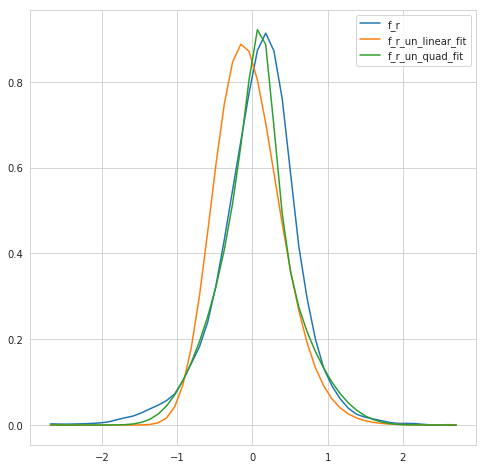

```python
test['f_r_un_linear_fit'] = [round(calc_density(x=elem, r=0, T=20/260, sigma=sigma_func_linear(elem, un_linear_a, un_linear_b), delta_x=0.01), 4) for elem in test['r']]
test['f_r_un_quad_fit'] = [round(calc_density(x=elem, r=0, T=20/260, sigma=sigma_func_quad(elem, un_quad_a, un_quad_b, un_quad_c), delta_x=0.01), 4) for elem in test['r']]

fig = plt.figure(figsize=(8, 8))
plt.plot(test['r'], test['f_r'])
plt.plot(test['r'], test['f_r_un_linear_fit'])
plt.plot(test['r'], test['f_r_un_quad_fit'])
plt.legend()
```

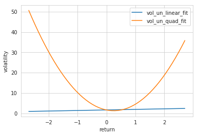

```python
test['vol_un_linear_fit'] = [sigma_func_linear(elem, un_linear_a, un_linear_b) for elem in test['r']]
test['vol_un_quad_fit'] = [sigma_func_quad(elem, un_quad_a, un_quad_b, un_quad_c) for elem in test['r']]

plt.plot(test['r'], test['vol_un_linear_fit'])
plt.plot(test['r'], test['vol_un_quad_fit'])
plt.legend()
plt.xlabel('return')
plt.ylabel('volatility')
```

#### Scipy Optimization (Bonuded) Result

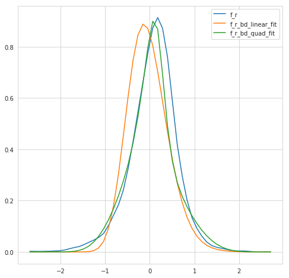

```python
test['f_r_bd_linear_fit'] = [round(calc_density(x=elem, r=0, T=20/260, sigma=sigma_func_linear(elem, bd_linear_a, bd_linear_b), delta_x=0.01), 4) for elem in test['r']]
test['f_r_bd_quad_fit'] = [round(calc_density(x=elem, r=0, T=20/260, sigma=sigma_func_quad(elem, bd_quad_a, bd_quad_b, bd_quad_c), delta_x=0.01), 4) for elem in test['r']]

fig = plt.figure(figsize=(8, 8))
plt.plot(test['r'], test['f_r'])
plt.plot(test['r'], test['f_r_bd_linear_fit'])
plt.plot(test['r'], test['f_r_bd_quad_fit'])
plt.legend()
```

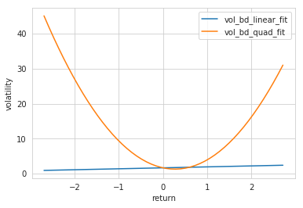

```python
test['vol_bd_linear_fit'] = [sigma_func_linear(elem, bd_linear_a, bd_linear_b) for elem in test['r']]
test['vol_bd_quad_fit'] = [sigma_func_quad(elem, bd_quad_a, bd_quad_b, bd_quad_c) for elem in test['r']]

plt.plot(test['r'], test['vol_bd_linear_fit'])
plt.plot(test['r'], test['vol_bd_quad_fit'])
plt.legend()
plt.xlabel('return')
plt.ylabel('volatility')
```

### Part 7: Construct Term Curve

Base on performance above, we chose to use the **unbounded scipy optimization** with **quadratic volatility function** to construct the volatility term curve.

[figure not shown]

```python
curve = pd.DataFrame(columns=['term', 'a', 'b', 'c'])
for k, v in terms.items():
    r_series = df['mean_' + k].dropna()
    term_day = v
    kde = KernelDensity(bandwidth=0.1)
    method = 'quad'
    obj_min = minimize(obj_func, (1, -1, 1), args=(r_series, term_day, kde, method), method='SLSQP')
    curve_un_quad_a, curve_un_quad_b, curve_un_quad_c = obj_min.x
    test['vol_un_quad_fit_' + k] = [sigma_func_quad(elem, curve_un_quad_a, curve_un_quad_b, curve_un_quad_c) for elem in test['r']]
    curve = curve.append({'term': v,
                          'a': round(curve_un_quad_a, 4),
                          'b': round(curve_un_quad_b, 4),
                          'c': round(curve_un_quad_c, 4)}, ignore_index=True)
#     plt.plot(test['r'], test['vol_un_quad_fit_' + k])
#
# plt.legend()
```

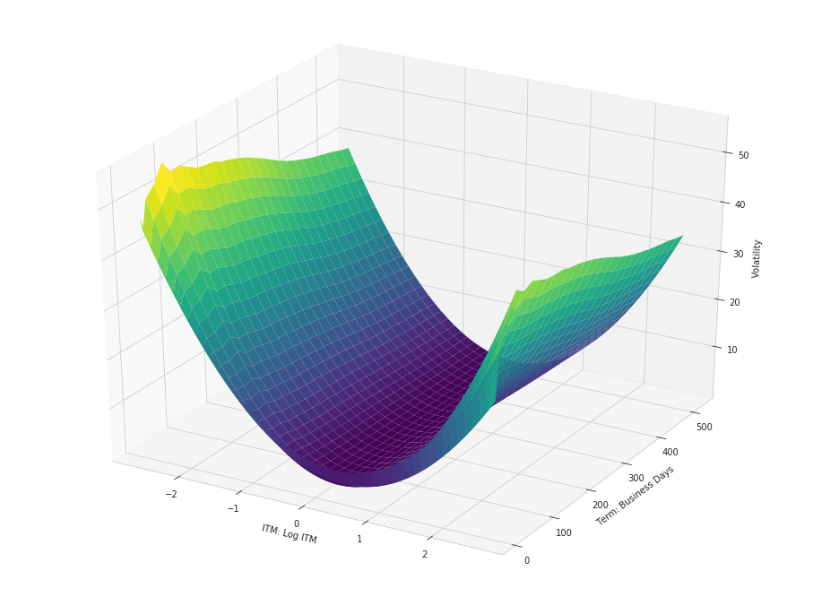

```python
def f(x, y):
    z = []
    for k, v in terms.items():
        for i in range(len(test['r'])):
            z.append(test['vol_un_quad_fit_' + k][i])
    return np.array(z)

x = test['r']
y = term_days
X, Y = np.meshgrid(x, y)
Z = f(X, Y).reshape(X.shape)


fig = plt.figure(figsize=(16, 12))
ax = plt.axes(projection='3d')
ax.plot_surface(X, Y, Z, rstride=1, cstride=1, cmap='viridis', edgecolor='none')
ax.set_xlabel('ITM: Log ITM')
ax.set_ylabel('Term: Business Days')
ax.set_zlabel('Volatility');
```